# Plot_TopDownData

Somak Ray

2023-11-02

**This script plots an S-curve for log-copy numbers for proteins from Olsen’s data and indicates the protein hits from our data in the plot. prints the percent of protein hits in each decile bin of Olsen’s data**

**Required Libraries**

```r
library(scales)
library("extrafont")
library(Cairo) # For anti-aliasing to increase sharpness in plots
library("pander") # For pretty printing sessionInfo
```

```r
rm(list = ls())
set.seed(12345)
setwd("E:\\SHOWCASE\\ASMS2022\\EDIT_GIT")
```

**Read the input file**

```r
input_file <- "ASMS22_Input2R.Olsen2Match.Data.txt"
copynum.df <-
  read.table(
    input_file,
    header = TRUE,
    sep = "\t",
    stringsAsFactors = TRUE,
    check.names = TRUE,
    na.strings = ""
  )
```

**Information about the data**

```
## Dimensions of the data frame: 14178 2
```

**Head of the data frame:**

```
##   Log10Copynum Match2TopDown
## 1     7.778874       Present
## 2     7.698970       Present
## 3     7.662758       Present
## 4     7.592177       Present
## 5     7.514548       Present
## 6     7.463893       Present
```

**Tail of the data frame:**

```
##       Log10Copynum Match2TopDown
## 14173     1.383815        Absent
## 14174     1.255273        Absent
## 14175     1.217484        Absent
## 14176     1.173186        Absent
## 14177     1.146128        Absent
## 14178     1.155336        Absent
```

```
## Summary of the data frame: Min.   :1.146   1st Qu.:3.362   Median :4.068   Mean   :4.195   3rd Qu.:4.955   Max.   :7.779   Absent :13421   Present:  757   NA NA NA NA
```

**Sort by ascending Log10Copynum**

```r
# Sort by ascending Log10Copynum
copynum_lo2hi.df <-
  copynum.df[order(copynum.df$Log10Copynum, decreasing = FALSE), ]

# Count the number of 'Present' matches
num_present = table(copynum.df$Match2TopDown)["Present"]

# Setting color palette
rbPal <- colorRampPalette(c('red', 'orangered', 'purple', 'blue'))

copynum_lo2hi.df$chroma <-
  rev(rbPal(10)[as.numeric(cut(1:length(copynum_lo2hi.df$Log10Copynum), breaks = 10))])
```

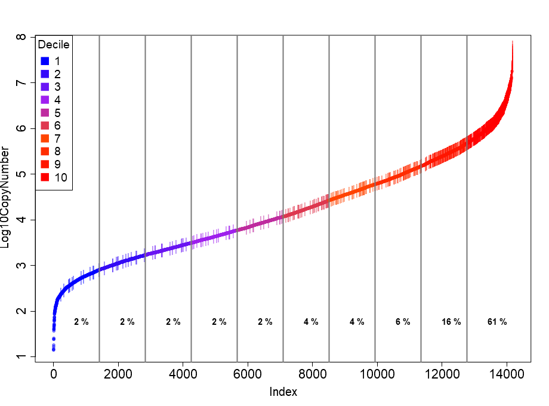

Decile Plot

```r
loadfonts()
#Calculate data deciles
deciles <-
  quantile((1:length(copynum_lo2hi.df$Log10Copynum)), probs = seq(.1, .9, by = .1))

# Plot figure with percent match or counts match for each decile
Cairo(
  file = "XBL_ASMS22_SCurve.png",
  type = 'png',
  width = 920,
  height = 680,
  family = "Arial"
)
plot(
  copynum_lo2hi.df$Log10Copynum,
  col = alpha(copynum_lo2hi.df$chroma, 0.50),
  pch = (c(20, charToRaw("|")))[copynum_lo2hi.df$Match2TopDown],
  cex = c(1.0, 2.0)[copynum_lo2hi.df$Match2TopDown],
  cex.axis = 1.8,
  cex.lab = 1.6,
  xlab = 'Index',
  ylab = 'Log10CopyNumber'
)


abline(
  v = deciles,
  lty = 1,
  col = 'grey47',
  lwd = 2
)

# Calculate bin limits and annotate the plot with match counts or percentages
binlimits <- round(unname(deciles), 0)
begin <- c(1)
right <- numeric()

for (val in binlimits) {
  right <- c(right, val)
  begin <- c(begin, val + 1)
}

right <- c(right, length(copynum_lo2hi.df$Log10Copynum))
stopifnot(length(begin) == length(right))
#legend_choice = 'count'
legend_choice = 'pct'

for (i in 1:length(begin)) {
  sub.df <- copynum_lo2hi.df[begin[i]:right[i], ]
  midbin <- begin[i] + round(((right[i] - begin[i]) / 2.0), 0)
  matchcount <- sum(sub.df$Match2TopDown == "Present")
  percentMatch <- (matchcount / num_present) * 100
  percentMatch <- round(percentMatch, 0)
  if (legend_choice == 'count') {
    legend(
      x = midbin - 550,
      y = 2.0,
      legend = paste0(matchcount),
      cex = 1.2,
      text.font = 2,
      xjust = 0
    )
  } else {
    legend(
      x = midbin - 550,
      y = 2.0,
      legend = paste0(percentMatch, " %"),
      cex = 1.2,
      text.font = 2,
      xjust = 0,
      bty = "n"
    )
  }
}

# Add legend for deciles
legend(
  "topleft",
  title = "Decile",
  legend = c(1:10),
  col = rev(rbPal(10)),
  pch = 15,
  cex = 1.5,
  pt.cex = 2.5
)


dev.off()
```

**R version 4.3.1 (2023-06-16 ucrt)**

**Platform:** x86_64-w64-mingw32/x64 (64-bit)

**locale:** *LC_COLLATE=English_United States.utf8*, *LC_CTYPE=English_United States.utf8*, *LC_MONETARY=English_United States.utf8*, *LC_NUMERIC=C* and *LC_TIME=English_United States.utf8*

**attached base packages:** *stats*, *graphics*, *grDevices*, *utils*, *datasets*, *methods* and *base*

**other attached packages:** *pander(v.0.6.5)*, *Cairo(v.1.6-2)*, *extrafont(v.0.19)* and *scales(v.1.3.0)*

**loaded via a namespace (and not attached):** *cli(v.3.6.1)*, *knitr(v.1.45)*, *rlang(v.1.1.2)*, *xfun(v.0.41)*, *Rttf2pt1(v.1.3.12)*, *jsonlite(v.1.8.8)*, *glue(v.1.7.0)*, *colorspace(v.2.1-0)*, *extrafontdb(v.1.0)*, *htmltools(v.0.5.7)*, *sass(v.0.4.9)*, *rmarkdown(v.2.26)*, *evaluate(v.0.23)*, *munsell(v.0.5.0)*, *jquerylib(v.0.1.4)*, *fastmap(v.1.1.1)*, *yaml(v.2.3.8)*, *lifecycle(v.1.0.4)*, *compiler(v.4.3.1)*, *Rcpp(v.1.0.12)*, *rstudioapi(v.0.16.0)*, *farver(v.2.1.1)*, *digest(v.0.6.33)*, *R6(v.2.5.1)*, *bslib(v.0.6.2)*, *tools(v.4.3.1)* and *cachem(v.1.0.8)*